# Comparison of LSD and BEAST dating methods for UK data

Erik Volz

April 11, 2016

# Procedure for picking cluster

- Cluster of n = 153 was selected using the UCSD tool and a TN93 threshold of 2%
- This was the 2nd largest cluster and was selected because it had good diversity of sample dates and a moderate sample size

# Procedure for BEAST

- GTR + Gamma + I substitution model
- Uncorrelated lognormal relaxed clock
- Skyride coalescent prior
- 150e6 iterations, sampling 1e4 iterations
- 100 trees sampled randomly from posterior with a burn-in of 33%
- Convergence assessed using Tracer
- Minimum ESS among all parameters was 332 for root height

Note that the mean rate was estimated to be 0.00161695, which is similar to what SLV found using LSD.

# Procedure for LSD

- I used SLVs LSD trees, so SLV can comment on particular parameter choices
- Clade was extracted corresponding to the cluster for each bootstrap tree

# Analysis

Read the tip dates

```
require(phydynR)
tre <- read.tree( 'clusterForBEAST0.phyml_boot_trees.nwk')[[1]]
dates <- setNames(sapply( tre$tip.label, function(w){
    as.numeric(strsplit(w, '_')[[1]][2]) / 365
}), tre$tip.label)
```

Extract the clade corresponding to the cluster from Stephanes LSD trees

```
lsdinclude <- sapply( strsplit( names(dates), '_') , function(spl) spl[1] ) # tip names
lsddates <- setNames( dates, lsdinclude ) # dates for lsd tree
lsdfns <- list.files(path='slv_lsd', pattern='result.date.newick', full.names=T)
lsdbdts <- lapply( lsdfns , function(fn){
    tre <- read.tree(fn)
    tre <- drop.tip(tre, setdiff(  tre$tip.label, lsdinclude)  )
    DatedTree( tre, lsddates[tre$tip.label], tol = 1)
})
```

Load the BEAST trees

```
beasttrees <- read.nexus( 'clusterForBEAST0.fasta.trees' )
beasttrees <- beasttrees[floor(seq(5e3,length(beasttrees),length.out=100))]
beastbdts <- lapply( beasttrees, function(tre) {
    tre$edge.length <- tre$edge.length / 365
    DatedTree( tre, dates[tre$tip.label] , tol = 1)
})
```

The above has been precomputed, so load the trees here:

```r
load('beastLSDComparison/clusterForBeast-anal0.RData')
suppressPackageStartupMessages( require(phydynR) )
```

Make a LTT plot

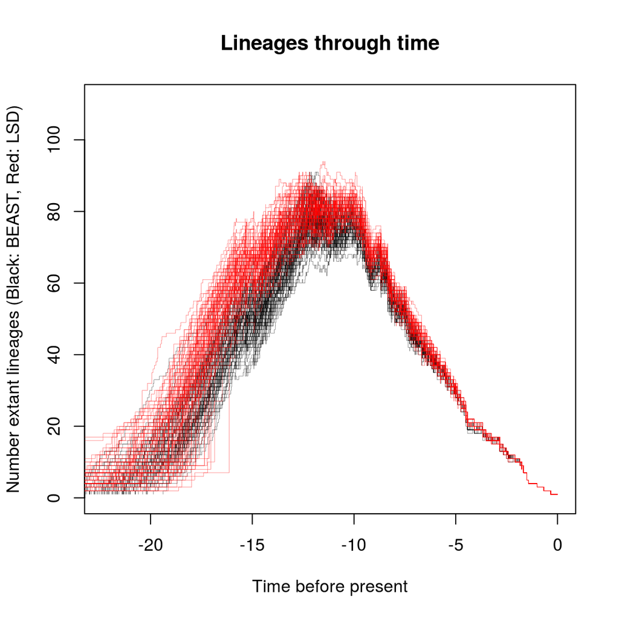

```r
ltt.plot( beastbdts[[1]] , lwd = .2 , ylim = c(0, 111)
 , main = 'Lineages through time'
 , ylab = 'Number extant lineages (Black: BEAST, Red: LSD)'
 , xlab = 'Time before present')
for (i in 2:length(beastbdts)){
    ltt.lines( beastbdts[[i]] , lwd = .2)
}
for (i in 1:length(lsdbdts)){
    ltt.lines( lsdbdts[[i]], col = 'red', lwd = .2 )
}
```

Make a QQ plot of internal node heights:

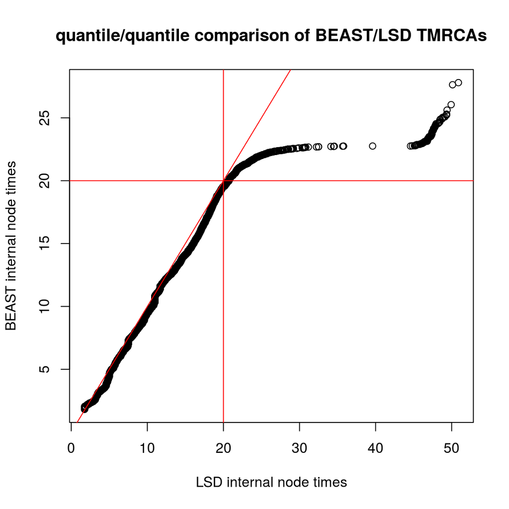

```r
n <- 153
Nnode <- 152
beastHeights <- unname( unlist( lapply( beastbdts, function(bdt) bdt$heights[(n+1):(n+Nnode)] ) ) )
lsdHeights <- unname( unlist( lapply( lsdbdts, function(bdt) bdt$heights[(n+1):(n+Nnode)] ) ) )
qqplot( lsdHeights, beastHeights , xlab = 'LSD internal node times'
, ylab = 'BEAST internal node times'
, main = 'quantile/quantile comparison of BEAST/LSD TMRCAs')
abline( a = 0, b = 1, col = 'red')
abline ( h = 20 , col = 'red')
abline ( v = 20, col = 'red' )
```

# Summary & interpretation

A few observations

- It’s interesting LSD using bootstrap ML actually has higher variance in the LTT than BEAST; often people are worried about ML methods underestimating variance compared to Bayes methods
- The correspondence in LTT is okay for most of the cluster history, but deviates substantially after 20 years
- Fortunately, 20 years is the threshold we used for SA analysis, and for <20 years, the LSD and BEAST trees correspond quite closely.

I think we can be confident that LSD worked well enough for our purposes.